# Regresja liniowa

Marcin Mazurek

2017-10-20

# Regresja liniowa

Przykładowy zbiór danych: Boston z biblioteki MASS (zrodlo:http://lib.stat.cmu.edu/datasets/boston)

```r
library(MASS)
head(Boston)
```

```
##      crim zn indus chas   nox    rm  age    dis rad tax ptratio  black
## 1 0.00632 18  2.31    0 0.538 6.575 65.2 4.0900   1 296    15.3 396.90
## 2 0.02731  0  7.07    0 0.469 6.421 78.9 4.9671   2 242    17.8 396.90
## 3 0.02729  0  7.07    0 0.469 7.185 61.1 4.9671   2 242    17.8 392.83
## 4 0.03237  0  2.18    0 0.458 6.998 45.8 6.0622   3 222    18.7 394.63
## 5 0.06905  0  2.18    0 0.458 7.147 54.2 6.0622   3 222    18.7 396.90
## 6 0.02985  0  2.18    0 0.458 6.430 58.7 6.0622   3 222    18.7 394.12
##   lstat medv
## 1  4.98 24.0
## 2  9.14 21.6
## 3  4.03 34.7
## 4  2.94 33.4
## 5  5.33 36.2
## 6  5.21 28.7
```

## Założenia regresji liniowej

Przypuśćmy, ze wpływy każdej rozpatrywanej zmiennej objaśniającej na zmienną objaśnianą jest liniowy i nie zależy od wartości innych zmiennych. Wartość $y_i$ traktujemy jako wartość zmiennej losowej $Y_i$.

Liniowy model regresji wielokrotnej:

$Y_i=\alpha_0+\alpha_1 * x_{1,i} + \alpha_2 * x_{2,i} + \dots + \alpha_{m,i} * x_{m,i} + \epsilon_i$,

gdzie:  
$\alpha_0, \dots, \alpha_m$ nieznane parametry,  
$\epsilon_i$ dla $i=1,\dots, n$ błędy losowe o takim samym rozkładzie mającym wartość średnią 0 i nieznaną, stałą wariancję $\sigma^2$

$n$ liczba obserwacji  
$m$ liczba zmiennych niezależnych  
$p=m+1$ liczba parametrów modelu

## Budowa modelu

### Podzial zbioru na ciag uczący i testowy

```r
train.idx <-sample (1:nrow(Boston), 0.7*nrow(Boston), replace = FALSE)
train<-Boston[train.idx, ]
test<-Boston[-train.idx, ]

nrow(train)
```

```
## [1] 354
```

```r
nrow(test)
```

```
## [1] 152
```

```r
#
#model$fitted.values
#plot(model$fitted.values, df$medv)
#plot(model)
#model.matrix.default()
```

### Model regresji liniowej

```r
model<-lm(medv~age, data=train)
summary(model)
```

```
##
## Call:
## lm(formula = medv ~ age, data = train)
##
## Residuals:
##     Min      1Q  Median      3Q     Max
## -15.083  -5.116  -1.774   2.160  31.341
##
## Coefficients:
##             Estimate Std. Error t value Pr(>|t|)
## (Intercept) 30.93089    1.19615  25.859  < 2e-16 ***
## age         -0.12272    0.01601  -7.665 1.76e-13 ***
## ---
## Signif. codes:  0 '***' 0.001 '**' 0.01 '*' 0.05 '.' 0.1 ' ' 1
##
## Residual standard error: 8.35 on 352 degrees of freedom
## Multiple R-squared:  0.143,  Adjusted R-squared:  0.1406
## F-statistic: 58.75 on 1 and 352 DF,  p-value: 1.757e-13
```

Model:  
* Wartości współczynników (estymatory)  
* Błąd standardowy współczynników  
* Wartość statystyki t  
* p-value dla współczynników

Ocena jakości modelu  
* Istotność parametrów  
* Wartość współczynnika $R^2$

### Rozkład całkowitej zmienności zmiennej objaśnianej

- Całkowita suma kwadratów (total sum of squares)

$SST=\sum_{i=1}^{n}(y_i-\overline{y})^2$

```r
y_mean <-mean(train$medv)
SST <- sum((train$medv - y_mean)^2)
SST
```

```
## [1] 28635.53
```

$SST = SSE + SSR$  
Równość powyższa zachodzi w sytuacji, gdy $y_i$ oznaczają wartości przewidywane obliczne na podstawie prostej MNK i nie musi być spełniona dla innej prostej przybliżającej chmurę punktów.

- Suma kwadratów błędów (error sum of squares)  
  $SSE=\sum_{i=1}^{n}(y_i-\hat{y_i})^2$

Indeks zmienności wartości $y_i$ nie wyjaśnionej przez zależność liniową.

```r
SSE <- sum ((train$medv - model$fitted.values )^2)
SSE
```

```
## [1] 24539.58
```

```r
SSE <-sum(model$residuals^2)
SSE
```

```
## [1] 24539.58
```

- Regresyjna suma kwadratów (regression sum of squares)  
  $SSR=\sum_{i=1}^{n}(\hat{y_i}-\overline{y})^2$

```r
SSR <- sum (( model$fitted.values - y_mean )^2)
SSR
```

```
## [1] 4095.951
```

```r
SSE + SSR
```

```
## [1] 28635.53
```

- Współczynnik determinacji $R^2$  
  $R^2=\frac{SSR}{SST}=1-\frac{SSE}{SST}$

```r
R2<- SSR/SST
R2
```

```
## [1] 0.1430374
```

- Skorygowany współczynnik determinacji - uwzględnia liczbę zmiennych w modelu

```r
n<-nrow(train)
p<-2
R2_adj<- 1 - (1-R2)*(n-1)/(n-p)
R2_adj
```

```
## [1] 0.1406028
```

- MSR

$MSR=\frac{SSR}{m}$

```r
MSR<- SSR/(1)
MSR
```

```
## [1] 4095.951
```

- Błąd średniokwadratowy, MSE (Mean Square Error), SE (Standard Error)

Nieobciążony estymator wariancji $\sigma^2$

$MSE=\frac{SSE}{n-p}$

```r
MSE<- SSE/(n-p)
MSE
```

```
## [1] 69.71472
```

- Statystyka F

Badanie liniowej zależności pomiędzy zmienną celu a zbiorem zmiennych objaśniających traktyowanych jako całość. Hipoteza zerowa: $H_{0}: \alpha_1=\alpha_2=\dots=\alpha_m=0$  
Hipoteza alternatywna: $H_{1}:$ istnieje przynajmniej jeden współczynnik $\alpha_i \ne 0$

Statystyka F:

$F=\frac{MSR}{MSE}$

```r
F<-MSR/MSE
F
```

```
## [1] 58.75303
```

Rozkład gęstości i dystrybuanta:

```r
F<-MSR/MSE
F
```

```
## [1] 58.75303
```

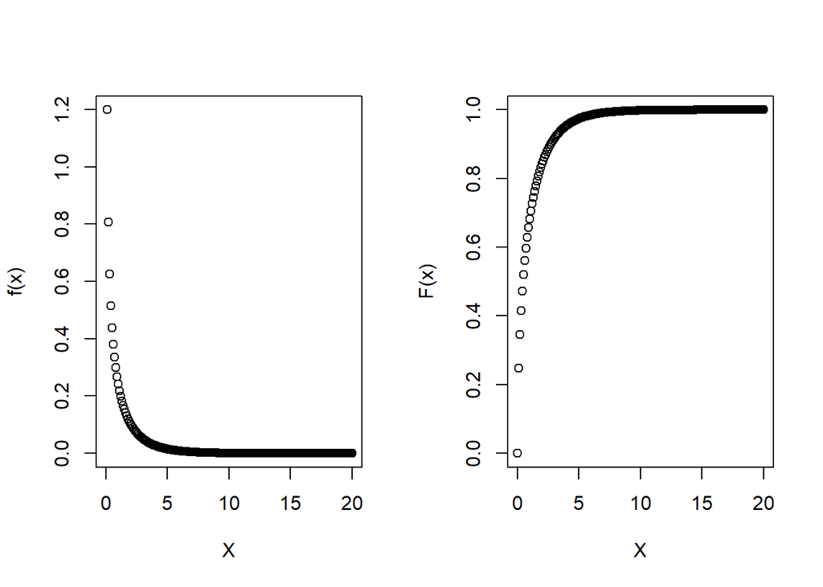

```r
par(mfrow=c(1,2))

plot(seq(0,20,0.1), df(seq(0,20,0.1),p-1,n-p), xlab="X", ylab="f(x)" )

plot(seq(0,20,0.1), pf(seq(0,20,0.1),p-1,n-p),xlab="X", ylab="F(x)" )
```

Obszar krytyczny: ${F: F \ge f_{1-\alpha, p-1, n-p}}$

na poziomie istotności 0.05:

```r
qf(0.95, p-1, n-p)
```

```
## [1] 3.868012
```

- p-value modelu

Jaki jest graniczny poziom istotności, przy którym hipoteza zerowa zostałaba odrzucona ?

```r
pf(F, p-1, n-p,     lower.tail=FALSE)
```

```
## [1] 1.757375e-13
```

### Weryfikacja hipotezy o istotności współczynników

Współczynniki i błędy standardowe współczynników:

```r
alfa<-model$coefficients
alfa
```

```
## (Intercept)         age
##  30.9308895  -0.1227233
```

```r
alfa_se<-sqrt(diag(vcov(model)))
alfa_se
```

```
## (Intercept)         age
##  1.19615087  0.01601076
```

#### Statystyka t

$t_i=\frac{\alpha_i}{SE_{\alpha_{i}}}$

```r
t<-alfa/alfa_se
t
```

```
## (Intercept)         age
##   25.858686   -7.665052
```

#### Hipoteza zerowa

Hipoteza zerowa: $H_{0}: \alpha_i=0$

Hipoteza alternatywna: $H_{1}: \alpha_i \neq 0$

Statystyka testowa t przy ma przy prawdziwości hipotezy H0 rozkład $T_{n-2}$

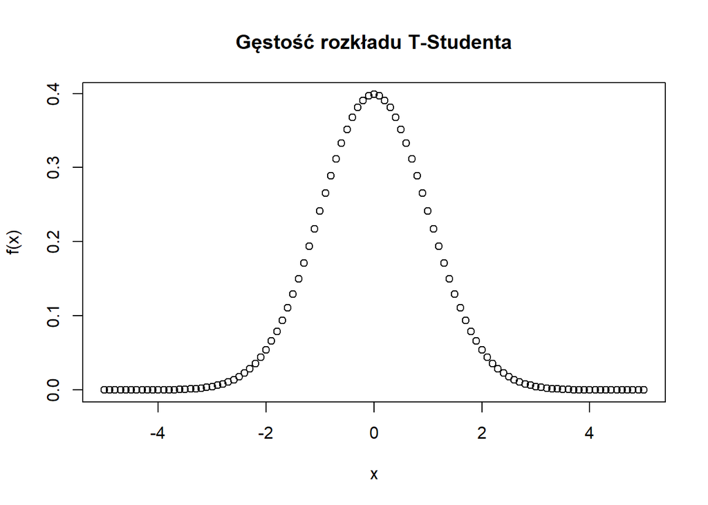

```r
plot(seq(-5,5,0.1), dt(seq(-5,5,0.1), df=n-p), xlab="x", ylab="f(x)", main="Gęstość rozkładu T-Studenta")
```

Obszar krytyczny:

$\{{t: |{t}| \ge t_{{1-\frac{\alpha}{2}},n-p}}\}$

Obszar krytyczny na poziomie istotności 0.05 (granica):

```r
t_gr<-qt(1-0.05/2, df=n-p)
t_gr
```

```
## [1] 1.966726
```

Ponieważ wartość statystyki t wpada do obszru krytycznego, hipotezę zerową należy odrzucić. Oznacza, to że nie ma podstaw do wnioskowania, że parametr jest nieistotny.

#### p-value

```r
p_value<-2*pt(-abs(t), df=n-p, lower.tail=TRUE)
p_value
```

```
##  (Intercept)          age
## 2.223914e-83 1.757375e-13
```

## Weryfikacja założeń regresji liniowej

### Wartości resztowe (residuals)

- Różnica między wartością zmiennej objaśniającej Y dla i-tej obserwacji i odpowiednią wartoscią przewidywaną:

$e_i=y_i-\hat{y_i}$

```r
#wartości prognozowane oraz reszty

y_pred<- model$fitted.values
head(y_pred)
```

```
##      461      110      246      150      334       68
## 19.88579 19.73853 22.31571 19.28445 26.25513 28.30461
```

```r
#Reszty
head(model$residuals)
```

```
##        461        110        246        150        334         68
## -3.4857935 -0.3385256 -3.8157146 -3.8844494 -4.0551322 -6.3046111
```

```r
y<-train$medv
e<- y - y_pred

head(e)
```

```
##        461        110        246        150        334         68
## -3.4857935 -0.3385256 -3.8157146 -3.8844494 -4.0551322 -6.3046111
```

### Obserwacje odstające (outliers, leverage)

Wpływ (leverage, hat-value):

$h_i=\frac{1}{n} + \frac{ ( x_i-\overline{x})^2}{\sum_{j=1}^{n} (x_j - \overline{x})^2 }$

Hat-Matrix H - projekcja Y na wartości przewidywane

$\hat{y_i}=h_{1,j}* y_1 + h_{2,j}*y_2+ \dots + h_{n,j} *y_n = \sum_{i=1}^n h_{i,j}*y_i$

```r
age_mean<-mean(train$age)
n<-nrow(train)

h <- 1/n + (train$age - age_mean)^2/sum((train$age - age_mean)^2)
head(h)
```

```
## [1] 0.004388676 0.004575964 0.002827347 0.005220099 0.006422025 0.011288801
```

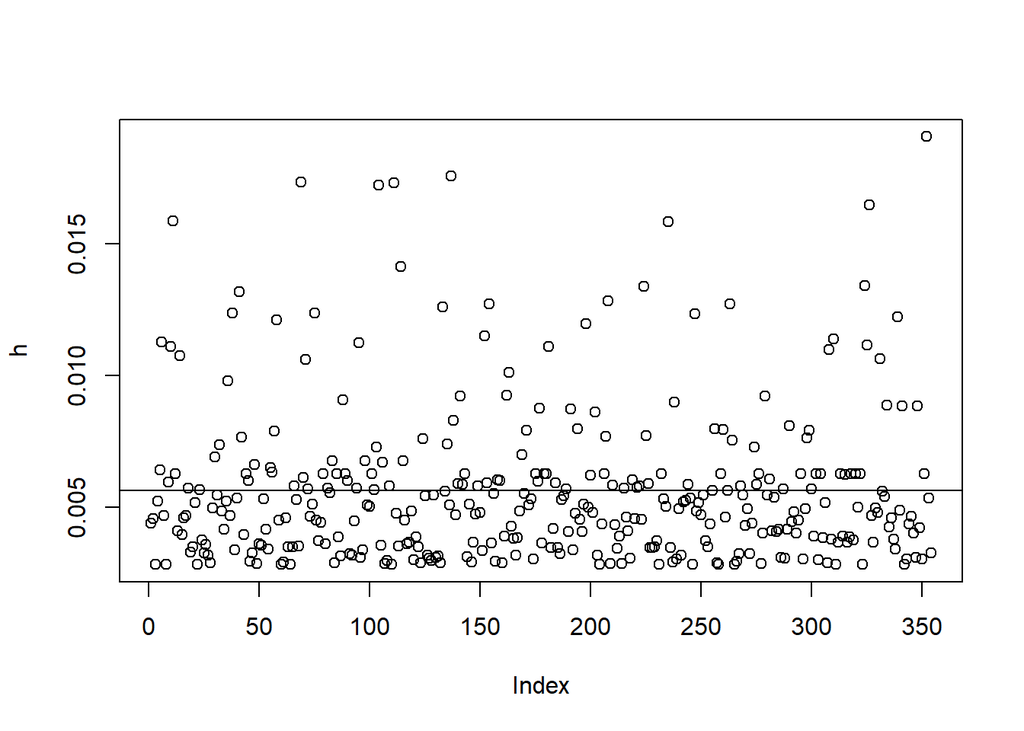

```r
plot(h)
abline(2/n,0)
```

Obserwacje odstające:

$h_i > \frac{2*p}{n}$

```r
h<-hatvalues(model)
head(h)
```

```
##         461         110         246         150         334          68
## 0.004388676 0.004575964 0.002827347 0.005220099 0.006422025 0.011288801
```

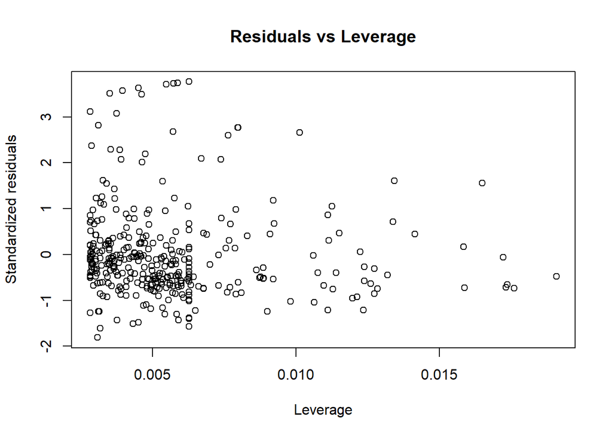

```r
plot(h, rstandard(model), xlab ="Leverage", ylab="Standardized residuals", main="Residuals vs Leverage")
```

### Obserwacje wpływowe (influential observations)

- Obserwacja wpływowa to taka, której usunięcie ze zbioru danych powoduje dużą zmianę wektora estymatorow regresji.
- Obserwacje odstające mogą być, ale nie muszą wpływowymi.
- Odleglość Cooke’a - wpływ, jaki na prognozę znanych wartości zmiennej objaśnianej ma usunięcie ze zbioru danych i-tej obserwacji:

$D_i=\frac{\sum_{j=1}^{n}(\hat{Y_j}-\hat{Y_{j(i)}}) }{m*S^2}$,  
gdzie  
$\hat{Y_{j(i)}}$ jest wartością przewidywaną dla j-tej obserwacji, obliczoną na podstawie danych z usuniętą obserwacją i-tą.

Diagram Cooke’a

```r
d<-cooks.distance(model)
head(d)
```

```
##          461          110          246          150          334
## 3.858360e-04 3.795725e-06 2.969174e-04 5.708594e-04 7.672266e-04
##           68
## 3.292085e-03
```

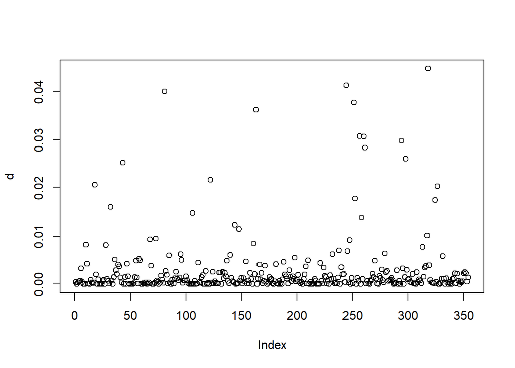

```r
plot(d)
```

### Homoskedastyczność czynnika losowego

Rozrzut punktów wokół wartości prognozowanych, sprawdzenie stałości wariancji składnika losowego (wykres scale-location)

[figure not shown]

```r
plot(model$fitted.values, model$residuals, xlab="Fitted values", ylab=" SQRT standardized residuals")
```

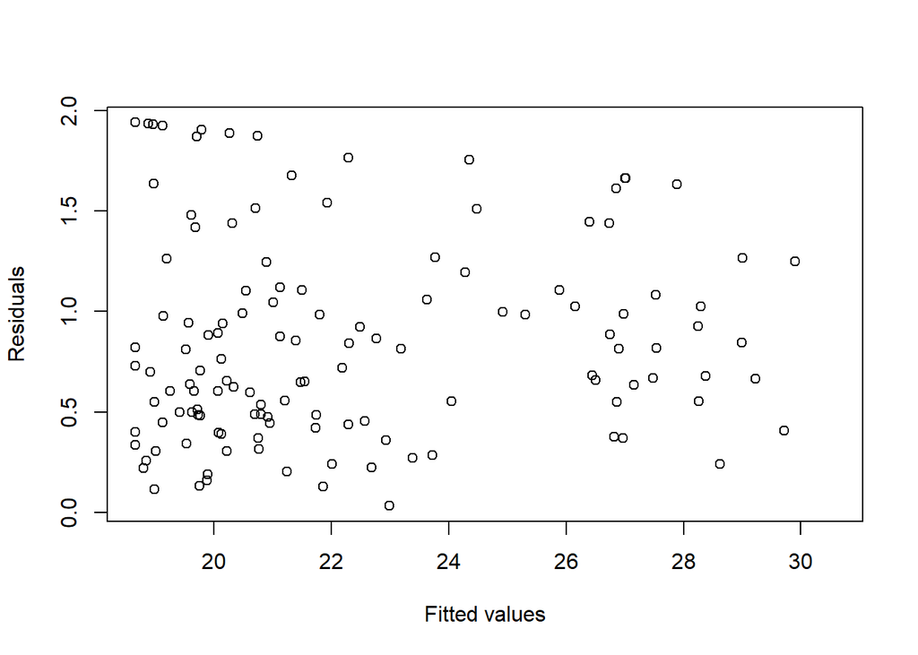

```r
plot( model$fitted.values, sqrt(rstandard(model)), xlab="Fitted values", ylab="Residuals")
```

### Wykresy kwantylowe - weryfikacja rozkładu normalnego składnika losowego

- Rezyduum ustandaryzowane (Standardized Residuals)

```r
e_std <- rstandard(model)
head(e_std)
```

```
##         461         110         246         150         334          68
## -0.41840272 -0.04063733 -0.45764473 -0.46644853 -0.48723873 -0.75938382
```

```r
e_std <- e/(MSE*sqrt(1-h))
head(e_std)
```

```
##          461          110          246          150          334
## -0.050110907 -0.004867018 -0.054810811 -0.055865217 -0.058355200
##           68
## -0.090949245
```

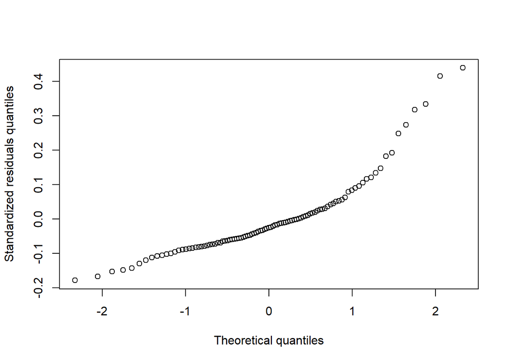

```r
eq<-quantile(e_std, seq(0.01,0.99, 0.01))
tq<-qnorm(seq(0.01,0.99, 0.01))


plot(tq, eq, xlab="Theoretical quantiles", ylab="Standardized residuals quantiles")
```

### Diagnostyka modelu

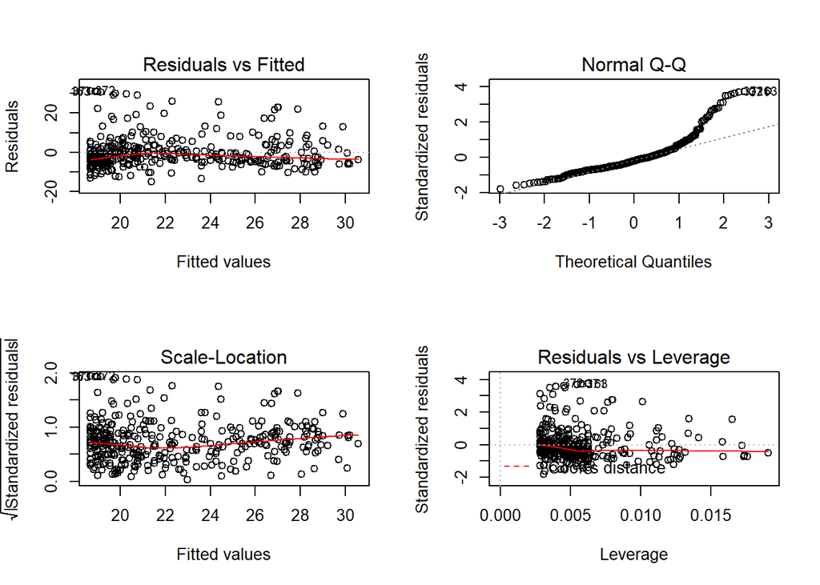

```r
par(mfrow=c(2,2))
plot(model)
```

## Regresja wieloraka

### Model

```r
model<-lm(medv~age+lstat+rad+crim, data=train)
summary(model)
```

```
##
## Call:
## lm(formula = medv ~ age + lstat + rad + crim, data = train)
##
## Residuals:
##     Min      1Q  Median      3Q     Max
## -10.291  -3.947  -1.444   1.897  24.906
##
## Coefficients:
##             Estimate Std. Error t value Pr(>|t|)
## (Intercept) 33.27788    0.90548  36.752   <2e-16 ***
## age          0.03196    0.01470   2.174   0.0304 *
## lstat       -0.96199    0.06042 -15.923   <2e-16 ***
## rad         -0.07221    0.05013  -1.440   0.1507
## crim        -0.05193    0.05227  -0.993   0.3212
## ---
## Signif. codes:  0 '***' 0.001 '**' 0.01 '*' 0.05 '.' 0.1 ' ' 1
##
## Residual standard error: 6.062 on 349 degrees of freedom
## Multiple R-squared:  0.5522, Adjusted R-squared:  0.547
## F-statistic: 107.6 on 4 and 349 DF,  p-value: < 2.2e-16
```

### Ocena jakości modelu na zbiorze testowym

[figure not shown]

```r
y_pred_test<- predict(model, test)

plot(y_pred_test, test$medv, xlab="Actual", ylab="Predicted")
abline(0,1)
```

*MAE - Mean Absolute Error

$MAE = \frac{1}{n}{\sum_{j=1}^{n}|y_j-\hat{y_j}|}$

- RMSE Root Mean Square Error  
  Mean Squared Prediction Error

```r
MAE <- (sum(abs(y_pred_test -  test$medv)) / nrow(test))
MAE
```

```
## [1] 4.591432
```

$RMSE = \sqrt {\frac{1}{n}\sum_{j=1}^{n}(y_j-\hat{y_j})^2}$

```r
RMSE <- sqrt (sum((y_pred_test -  test$medv)^2) / nrow(test))
RMSE
```

```
## [1] 6.404864
```